# Online Retail Analytics

*Setting default values to get a clean output*

```r
knitr::opts_chunk$set(message = FALSE)
knitr::opts_chunk$set(warning = FALSE)
```

*Loading all the required packages*

```r
library("VIM")
library("ISLR")
library("caret")
library("class")
library("e1071")
library("ggplot2")
library("corrplot")
library("dplyr")
```

*Setting working directory and loading data*

```r
setwd("/Users/sampathnikhilkumar/Desktop")
data.df <- read.csv("Online_Retail.csv")
```

*1.Show the breakdown of the number of transactions by countries*

```r
data_country <- as.data.frame(table(data.df$Country))

data_country$Percentage <- data_country$Freq/nrow(data.df) * 100

colnames(data_country) <- c("Country", "Count", "Percentage")

data_country[data_country$Percentage > 1,]
```

|  | Country | Count | Percentage |
| --- | --- | --- | --- |
| 11 | EIRE | 8196 | 1.512431 |
| 14 | France | 8557 | 1.579047 |
| 15 | Germany | 9495 | 1.752139 |
| 36 | United Kingdom | 495478 | 91.431956 |

*Countries accounting for more than 1% of the total transactions are EIRE, France, Germany and United Kingdom.*

*2. Adding new attribute “TransactionValue” which is the product of Quantity and UnitPrice*

```r
data.df$TransactionValue <- data.df$Quantity * data.df$UnitPrice
```

*By adding this new attribute we can now calculate the value of the transactions based on our requirement.*

*3. Using the newly created variable, TransactionValue, showing the breakdown of transaction values by countries with total transaction exceeding 130,000 British Pound*

```r
data.df %>% select(TransactionValue,Country) %>% group_by(Country) %>% summarise(Total = sum(TransactionValue)) %>% filter(Total >= 130000) %>% arrange((desc(Total)))
```

| Country | Total |
| --- | --- |
| United Kingdom | 8187806.4 |
| Netherlands | 284661.5 |
| EIRE | 263276.8 |
| Germany | 221698.2 |
| France | 197403.9 |
| Australia | 137077.3 |

*There are total 6 countries where the transaction value exceeds 130,000 British Pound and the highest among them is “United Kingdom”.*

*4. Converting Invoice Date into a POSIXlt object*

```r
Temp=strptime(data.df$InvoiceDate,format='%m/%d/%Y %H:%M',tz='GMT')
head(Temp)
```

```
[1] "2010-12-01 08:26:00 GMT" "2010-12-01 08:26:00 GMT"
[3] "2010-12-01 08:26:00 GMT" "2010-12-01 08:26:00 GMT"
[5] "2010-12-01 08:26:00 GMT" "2010-12-01 08:26:00 GMT"
```

```r
#New_Invoice_Date
data.df$New_Invoice_Date <- as.Date(Temp)

data.df$New_Invoice_Date[20000]- data.df$New_Invoice_Date[10]
```

```
Time difference of 8 days
```

```r
#Invoice_Day_Week
data.df$Invoice_Day_Week= weekdays(data.df$New_Invoice_Date)

#New_Invoice_Hour
data.df$New_Invoice_Hour = as.numeric(format(Temp, "%H"))

#New_Invoice_Month
data.df$New_Invoice_Month = as.numeric(format(Temp, "%m"))
```

*4(a). Percentage of transactions (by numbers) by days of the week*

```r
data.df %>% group_by(Invoice_Day_Week) %>% summarise(count=n()) %>% mutate(percentage=count/nrow(data.df)*100)
```

| Invoice_Day_Week | count | percentage |
| --- | --- | --- |
| Friday | 82193 | 15.16731 |
| Monday | 95111 | 17.55110 |
| Sunday | 64375 | 11.87930 |
| Thursday | 103857 | 19.16503 |
| Tuesday | 101808 | 18.78692 |
| Wednesday | 94565 | 17.45035 |

*4(b). Percentage of transactions (by transaction volume) by days of the week*

```r
data.df %>% group_by(Invoice_Day_Week) %>% summarise(Total = sum(TransactionValue)) %>% mutate(Percentage = Total/sum(Total)*100)
```

| Invoice_Day_Week | Total | Percentage |
| --- | --- | --- |
| Friday | 1540610.8 | 15.804787 |
| Monday | 1588609.4 | 16.297194 |
| Sunday | 805678.9 | 8.265282 |
| Thursday | 2112519.0 | 21.671867 |
| Tuesday | 1966182.8 | 20.170636 |
| Wednesday | 1734147.0 | 17.790232 |

*4(c). Percentage of transactions (by transaction volume) by month of the year*

```r
data.df %>% group_by(New_Invoice_Month) %>% summarise(Total = sum(TransactionValue)) %>% mutate(Percentage = Total/sum(Total) * 100)
```

| New_Invoice_Month | Total | Percentage |
| --- | --- | --- |
| 1 | 560000.3 | 5.744919 |
| 2 | 498062.7 | 5.109515 |
| 3 | 683267.1 | 7.009487 |
| 4 | 493207.1 | 5.059703 |
| 5 | 723333.5 | 7.420519 |
| 6 | 691123.1 | 7.090080 |
| 7 | 681300.1 | 6.989308 |
| 8 | 682680.5 | 7.003469 |
| 9 | 1019687.6 | 10.460751 |
| 10 | 1070704.7 | 10.984123 |

[output cut: 2 more lines]

*4(d). The date with the highest number of transactions from Australia*

```r
data.df %>% filter(Country =="Australia") %>% group_by(New_Invoice_Date) %>% summarise(Total_Count = n()) %>% arrange((desc(Total_Count)))
```

| New_Invoice_Date | Total_Count |
| --- | --- |
| 2011-06-15 | 139 |
| 2011-07-19 | 137 |
| 2011-08-18 | 97 |
| 2011-03-03 | 84 |
| 2011-10-05 | 82 |
| 2011-05-17 | 73 |
| 2011-02-15 | 69 |
| 2011-01-06 | 48 |
| 2011-07-14 | 35 |
| 2011-09-16 | 34 |

[output cut: 39 more lines]

*As we can see from above on 2011-06-15 Australia has recorded the highest number of transactions i.e. 139 Transactions.*

*5. Plot the histogram of transaction values from Germany*

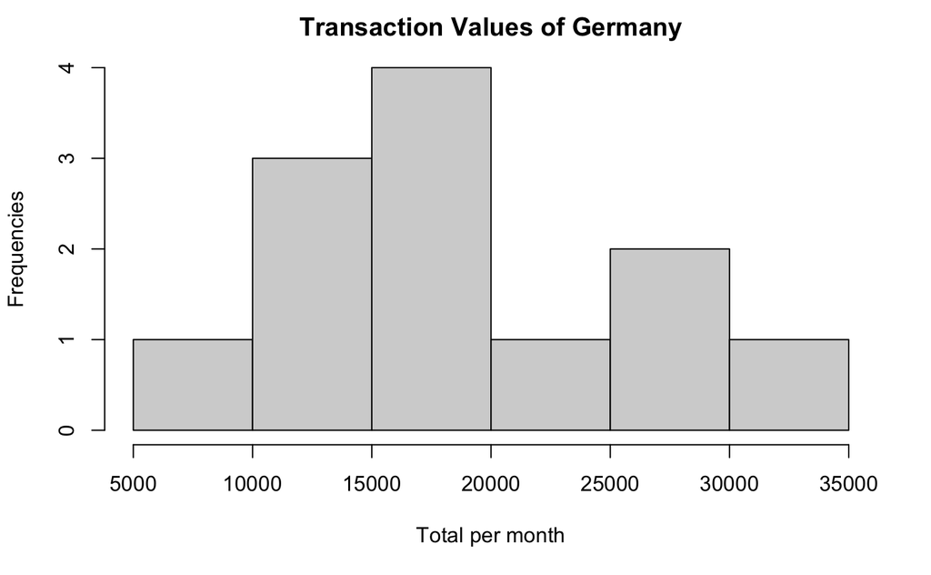

```r
Germany <- data.df %>% filter(Country == "Germany") %>% group_by(New_Invoice_Month) %>% summarise(Total=sum(TransactionValue))

hist(Germany$Total, main = "Transaction Values of Germany", xlab="Total per month", ylab="Frequencies")
```

*6(a). Customer who had highest number of transactions*

```r
data.df %>% group_by(CustomerID) %>% select(CustomerID) %>% filter(!is.na(CustomerID)) %>% summarise(n_count = n()) %>% arrange((desc(n_count)))
```

| CustomerID | n_count |
| --- | --- |
| 17841 | 7983 |
| 14911 | 5903 |
| 14096 | 5128 |
| 12748 | 4642 |
| 14606 | 2782 |
| 15311 | 2491 |
| 14646 | 2085 |
| 13089 | 1857 |
| 13263 | 1677 |
| 14298 | 1640 |

[output cut: 990 more lines]

*The CustomerID 17841 had the highest number of transactions amongst others with a total of 7983 transactions.*

*6(b). Most valuable customer with the highest total sum of transactions*

```r
data.df %>% group_by(CustomerID) %>% select(CustomerID, TransactionValue) %>% filter(!is.na(CustomerID)) %>% summarise(Spending_max = sum(TransactionValue)) %>% arrange((desc(Spending_max)))
```

| CustomerID | Spending_max |
| --- | --- |
| 14646 | 279489.020 |
| 18102 | 256438.490 |
| 17450 | 187482.170 |
| 14911 | 132572.620 |
| 12415 | 123725.450 |
| 14156 | 113384.140 |
| 17511 | 88125.380 |
| 16684 | 65892.080 |
| 13694 | 62653.100 |
| 15311 | 59419.340 |

[output cut: 990 more lines]

*The CustomerID 14646 is the most valuable customer with the highest spending sum of 279,489.020 British Sterling Pound.*

*7. Percentage of missing values for each variable in the dataset*

```r
colMeans(is.na(data.df)*100)
```

```
        InvoiceNo         StockCode       Description
          0.00000           0.00000           0.00000
         Quantity       InvoiceDate         UnitPrice
          0.00000           0.00000           0.00000
       CustomerID           Country  TransactionValue
         24.92669           0.00000           0.00000
 New_Invoice_Date  Invoice_Day_Week  New_Invoice_Hour
          0.00000           0.00000           0.00000
New_Invoice_Month
          0.00000
```

*We can observe that CustomerID is the only attribute with 24.9266% of NAs in the entire dataset.*

*8. The number of transactions with missing CustomerID records by Countries*

```r
data.df %>% filter(is.na(CustomerID)) %>% group_by(Country) %>% count()
```

| Country | n |
| --- | --- |
| Bahrain | 2 |
| EIRE | 711 |
| France | 66 |
| Hong Kong | 288 |
| Israel | 47 |
| Portugal | 39 |
| Switzerland | 125 |
| United Kingdom | 133600 |
| Unspecified | 202 |

*There are in total 8 countries and 1 unspecified country in the entire dataset which has NA values in them amongst these United Kingdom is the country with highest NA records of 133,600 rows.*

*9. On average, how often the costumers comeback to the website for their next shopping?*

```r
Diff_Days <- data.df %>% select(CustomerID,New_Invoice_Date) %>% group_by(CustomerID) %>% distinct(New_Invoice_Date) %>%  mutate(Days_Between = New_Invoice_Date-lag(New_Invoice_Date)) %>% filter(!is.na(Days_Between))

Diff_Days
```

| CustomerID | New_Invoice_Date | Days_Between |
| --- | --- | --- |
| 17850 | 2010-12-02 | 1 days |
| NA | 2010-12-02 | 1 days |
| 12748 | 2010-12-02 | 1 days |
| 15922 | 2010-12-02 | 1 days |
| 13767 | 2010-12-02 | 1 days |
| 17460 | 2010-12-02 | 1 days |
| 14911 | 2010-12-02 | 1 days |
| 17924 | 2010-12-02 | 1 days |
| 13408 | 2010-12-02 | 1 days |
| 16029 | 2010-12-02 | 1 days |

[output cut: 990 more lines]

```r
mean(Diff_Days$Days_Between)
```

```
Time difference of 38.4875 days
```

*On an average approximately for every 38 days customers come back to the website for their next shopping.*

*10. Return rate of goods purchased by the customers from France*

```r
France_Cancel <- data.df %>% filter(Country=="France",Quantity<0) %>% count()

France_Total <- data.df %>% filter(Country=="France") %>% count()

Return_Percentage_France <- France_Cancel/France_Total*100
Return_Percentage_France
```

| n |
| --- |
| 1.741264 |

*The return rate of customers who made purchases in France is 1.741264%.*

*11. The product that has generated the highest revenue for the retailer*

```r
data.df %>% select(StockCode,TransactionValue) %>% group_by(StockCode) %>%  summarise(Total=sum(TransactionValue)) %>% arrange((desc(Total)))
```

| StockCode | Total |
| --- | --- |
| DOT | 206245.48 |
| 22423 | 164762.19 |
| 47566 | 98302.98 |
| 85123A | 97894.50 |
| 85099B | 92356.03 |
| 23084 | 66756.59 |
| POST | 66230.64 |
| 22086 | 63791.94 |
| 84879 | 58959.73 |
| 79321 | 53768.06 |

[output cut: 990 more lines]

*The product with the StockCode as “DOT” is the one which has generated highest revenue to the retailer i.e. 206,245.48 British Sterling Pound.*

*12. Unique Customers in the dataset*

```r
data.df %>% select(CustomerID) %>% unique() %>% count()
```

| n |
| --- |
| 4373 |